# Degrees of Choice - Modification of WSJ Graphic

This post modifies a graph that appeared in an article from October 19, 2014 in the Wall Street Journal. The article was titled [“How to Sell a Liberal-Arts Education”](http://online.wsj.com/articles/how-a-college-president-sells-a-liberal-arts-education-1413751480). The post uses ggplot2 to create a static version of the modified graph and rCharts for an interactive version.

The article used the following grouped bar chart.

[figure not shown]

The intent of the graph is two fold.

1. To facilitate a comparison between the number of different bachelor’s degrees awarded, and
2. To facilitate a comparison between the percentage of students awarded with different bachelor’s degrees.

(One might also question whether the demand for a degree is accurately reflected by number of degrees awarded.)

## Iteration 1

This is the first attempt at modifying that graph, which is motivated by an example from [Stephen Few](http://www.perceptualedge.com/articles/visual_business_intelligence/save_the_pies_for_dessert.pdf).

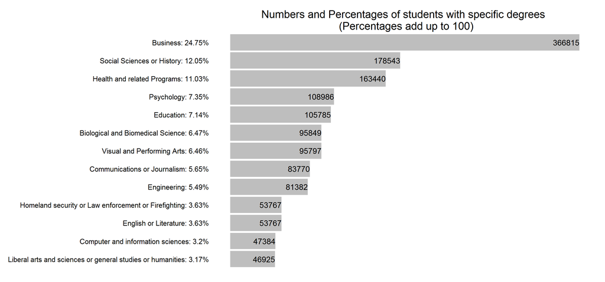

```r
library(ggplot2)
library(ggthemes)
library(rCharts)
suppressMessages(library(dplyr))
suppressMessages(library(gridExtra))
wsjdata=read.csv("wsjdata.csv")
wsjdata=wsjdata%>%mutate(Percentage=(Number*100/(sum(Number))))

ggplot(wsjdata,aes(reorder(Degree,Number),Number))+geom_bar(stat="identity",fill="grey")+geom_text(aes(label=Number),hjust=1)+ scale_x_discrete(breaks=reorder(wsjdata$Degree,wsjdata$Number), labels=paste(reorder(wsjdata$Degree,wsjdata$Number),": ",round(wsjdata$Percentage,2),"%",sep=""))+  coord_flip()+theme_tufte(base_family="sans", base_size=16, ticks=F)+theme(axis.title=element_blank(),axis.text.x=element_blank()) + ggtitle("Numbers and Percentages of students with specific degrees \n (Percentages add up to 100)")
```

The percentages we find in our calculation do not match up with what the original chart shows. In fact, percentage numbers from WSJ’s chart add up to 82.7%. They either did not include a catch-all “Other Degrees” category or did not compute the numbers correctly. In either case, there is an issue. [82.7% of 1792273.277 happens to be 1482210, the sum of students who graduated from degrees listed in the graphic. Thus, approximately 310063 students graduated with other degrees.]

In the following example, we assume those numbers from WSJ’s graphic to be correct and just separate the raw numbers from the percentages and show two different charts.

## Iteration 2

```r
rawplot=ggplot(wsjdata,aes(reorder(Degree,Number),Number))+geom_bar(stat="identity",fill="grey")+geom_text(aes(label=Number),hjust=1)+ coord_flip()+theme_tufte(base_family="sans", ticks=F)+ theme(axis.title=element_blank(),axis.text.x=element_blank(),axis.text.y=element_text(size=18)) + ggtitle("Numbers of students with specific degrees")

percentageplot=ggplot(wsjdata,aes(reorder(Degree,WSJPercent),WSJPercent))+geom_bar(stat="identity",fill="grey")+geom_text(aes(label=paste(WSJPercent,"%",sep="")),hjust=1)+ coord_flip()+theme_tufte(base_family="sans",ticks=F)+ theme(axis.title=element_blank(),axis.text=element_blank()) + ggtitle("Percentage of students with specific degrees")

grid.arrange(rawplot,percentageplot,ncol=2)
```

[figure not shown]

There is redundancy built in to the two plots and not much new information is gained, despite using a lot of space. I prefer the cleaner single-chart look. Here’s the last iteration of the static version, which is slightly different from the first version shown above.

## Iteration 3

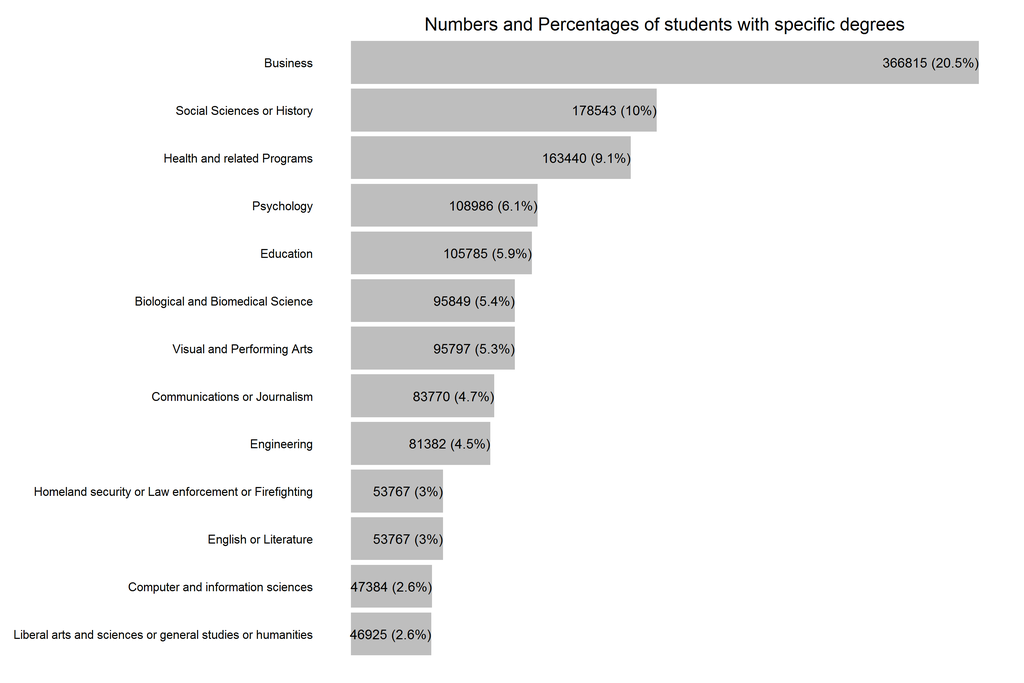

```r
ggplot(wsjdata,aes(reorder(Degree,Number),Number))+geom_bar(stat="identity",fill="grey")+geom_text(aes(label=paste(Number," (",WSJPercent,"%",")",sep="")),hjust=1) +coord_flip()+theme_tufte(base_family="sans", base_size=16, ticks=F)+theme(axis.title=element_blank(),axis.text.x=element_blank()) + ggtitle("Numbers and Percentages of students with specific degrees")
```

## Interactive Version (Please hover over the bars)

```r
np1=nPlot(Number~Degree,data=wsjdata,type ="multiBarHorizontalChart",height=800)
np1$chart(margin=list(top= 30, right= 20, bottom= 20, left=400),
          showLegend = FALSE, showControls=F,
          tooltipContent = "#! function(key, x, y, WSJPercent){
           return key + ':' + y + '<br>'+ 'Degree:' + x + '<br>'+ 'Percent:'+ WSJPercent        .point.WSJPercent} !#"
)
np1$yAxis(tickFormat="#!d3.format(',f')!#")
#np1$publish("np1wsjmod",host="gist")
```

[interactive chart not shown]